# Effect of smoking, sleep, and exercise habits on depression prevalence in Southwest America

#### Downloading the data from here:

https://www.kaggle.com/lplenka/brfss-data

#### Loading Libraries

- library(dplyr)
- library(tidyverse)
- library(plot3D)
- library(jtools)
- library(ggplot2)
- library(cowplot)
- library(corrplot)

#### Reading the data

- This dataset is about The Behavioral Risk Factor Surveillance System.

```r
sleep <- read.csv(file = "brfss2013.csv", header= TRUE, na.strings = c("","NA"))
```

#### Tidying data

- Specific columns were selected, and filtered based on the American Southwest states and ages(18-34).

```r
states <- c('Arizona','Texas','California','Nevada','New Mexico','Colorado','Utah','Utah')
ages <- c('Age 18 to 24','Age 25 to 29','Age 30 to 34')
dep <- sleep %>%
  filter(X_state == states,X_ageg5yr == ages)%>%
  select(X_state,addepev2, sleptim1,X_rfsmok3,exerany2,X_ageg5yr)
```

#### Checking the headers names

```r
names(dep)
```

```
## [1] "X_state"   "addepev2"  "sleptim1"  "X_rfsmok3" "exerany2"  "X_ageg5yr"
```

#### Renaming the headers

- Since the headers label were inappropriate.

```r
colnames(dep)[1] <- "State"
colnames(dep)[2] <- "DepressionY"
colnames(dep)[3] <- "Sleep_DurationX"
colnames(dep)[4] <- "SmokingX"
colnames(dep)[5] <- "ExercisingX"
colnames(dep)[6] <- "Age"
```

#### Checking for null values in each column

- The State column

```r
sum(is.na(dep$State))
```

```
## [1] 0
```

- The Depression column

```r
sum(is.na(dep$DepressionY))
```

```
## [1] 4
```

- The Sleep Duration column

```r
sum(is.na(dep$Sleep_DurationX))
```

```
## [1] 3
```

- The Smoking column

```r
sum(is.na(dep$SmokingX))
```

```
## [1] 27
```

- The Exercising column

```r
sum(is.na(dep$ExercisingX))
```

```
## [1] 55
```

- The Age column

```r
sum(is.na(dep$Age))
```

```
## [1] 0
```

#### Dealing with missing observations

- The total number of the NA values is not too high, so we will drop them.

```r
dep <- na.omit(dep)
```

- Printing the first rows of the dataset to check that everything is good.

```r
head(dep)
```

```
##     State DepressionY Sleep_DurationX SmokingX ExercisingX          Age
## 1 Arizona          No               6       No         Yes Age 25 to 29
## 2 Arizona          No               7       No         Yes Age 18 to 24
## 4 Arizona          No               8       No         Yes Age 18 to 24
## 5 Arizona          No               7       No         Yes Age 30 to 34
## 6 Arizona          No               8       No         Yes Age 30 to 34
## 7 Arizona          No               8       No          No Age 30 to 34
```

#### Converting the yes and No to 1 and 0

```r
dep$DepressionY <- ifelse(dep$DepressionY=="No",0,1)
dep$SmokingX <- ifelse(dep$SmokingX=="No",0,1)
dep$ExercisingX <- ifelse(dep$ExercisingX=="No",0,1)
head(dep)
```

```
##     State DepressionY Sleep_DurationX SmokingX ExercisingX          Age
## 1 Arizona           0               6        0           1 Age 25 to 29
## 2 Arizona           0               7        0           1 Age 18 to 24
## 4 Arizona           0               8        0           1 Age 18 to 24
## 5 Arizona           0               7        0           1 Age 30 to 34
## 6 Arizona           0               8        0           1 Age 30 to 34
## 7 Arizona           0               8        0           0 Age 30 to 34
```

#### Taking a look at the dataset

```r
str(dep)
```

```
## 'data.frame':    624 obs. of  6 variables:
##  $ State          : chr  "Arizona" "Arizona" "Arizona" "Arizona" ...
##  $ DepressionY    : num  0 0 0 0 0 0 0 0 0 1 ...
##  $ Sleep_DurationX: int  6 7 8 7 8 8 7 8 9 9 ...
##  $ SmokingX       : num  0 0 0 0 0 0 0 0 0 0 ...
##  $ ExercisingX    : num  1 1 1 1 1 0 1 1 1 0 ...
##  $ Age            : chr  "Age 25 to 29" "Age 18 to 24" "Age 18 to 24" "Age 30 to 34" ...
##  - attr(*, "na.action")= 'omit' Named int [1:64] 3 12 23 36 37 48 55 57 63 68 ...
##   ..- attr(*, "names")= chr [1:64] "3" "12" "23" "36" ...
```

#### Summary Statistics

```r
summary(dep)
```

```
##     State            DepressionY     Sleep_DurationX     SmokingX
##  Length:624         Min.   :0.0000   Min.   : 3.000   Min.   :0.000
##  Class :character   1st Qu.:0.0000   1st Qu.: 6.000   1st Qu.:0.000
##  Mode  :character   Median :0.0000   Median : 7.000   Median :0.000
##                     Mean   :0.1667   Mean   : 7.082   Mean   :0.141
##                     3rd Qu.:0.0000   3rd Qu.: 8.000   3rd Qu.:0.000
##                     Max.   :1.0000   Max.   :12.000   Max.   :1.000
##   ExercisingX         Age
##  Min.   :0.0000   Length:624
##  1st Qu.:1.0000   Class :character
##  Median :1.0000   Mode  :character
##  Mean   :0.8478
##  3rd Qu.:1.0000
##  Max.   :1.0000
```

#### Studying the distribution by building confusion matrix

```r
xtabs(~ SmokingX+DepressionY,data=dep)
```

```
##         DepressionY
## SmokingX   0   1
##        0 457  79
##        1  63  25
```

```r
xtabs(~ ExercisingX+DepressionY,data=dep)
```

```
##            DepressionY
## ExercisingX   0   1
##           0  79  16
##           1 441  88
```

#### Multiple Linear Regression on Sleep Duration and Depression

- This model shows a multiple linear regression, and provides insight into the reversibility of predictors and responses.

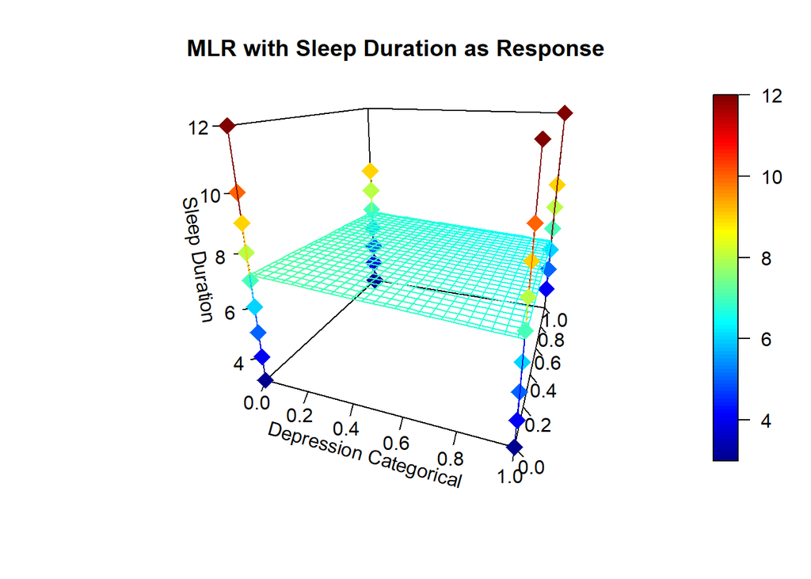

```r
# x, y, z variables
x <- dep$DepressionY
y <- dep$SmokingX
z <- dep$Sleep_DurationX
# Compute the linear regression (z = ax + by + d)
fit <- lm(z ~ x + y)
# predict values on regular x-y grid
grid.lines = 26
x.pred <- seq(min(x), max(x), length.out = grid.lines)
y.pred <- seq(min(y), max(y), length.out = grid.lines)
xy <- expand.grid( x = x.pred, y = y.pred)
z.pred <- matrix(predict(fit, newdata = xy),
                 nrow = grid.lines, ncol = grid.lines)
# fitted points for drop lines
fitpoints <- predict(fit)
# scatter plot with regression plane
scatter3D(x, y, z, pch = 18, cex = 2,
    theta = 20, phi = 20, ticktype = "detailed",
    xlab = "Depression Categorical", ylab = "", zlab = "Sleep Duration",
    surf = list(x = x.pred, y = y.pred, z = z.pred,
    facets = NA, fit = fitpoints), main = "MLR with Sleep Duration as Response")
```

#### Logistic Regression on Depression and It’s Effects (Sleeping Duration,Smoking,and Exercising)

- The below model is predicting Depression with the sleep, smoking, and exercise habits variables. The “Effects” x-axis is simply a staggering of the individuals in the dataset, and this plot shows the relative distribution of probabilities for depressed and not depressed individuals. We can see the model predicts a vast majority of the individuals to have a 10-20% chance of having depression diagnosis.

```r
log1 = glm(DepressionY ~ Sleep_DurationX+SmokingX+ExercisingX, data = dep, family = binomial)
summary(log1)
```

```
##
## Call:
## glm(formula = DepressionY ~ Sleep_DurationX + SmokingX + ExercisingX,
##     family = binomial, data = dep)
##
## Deviance Residuals:
##     Min       1Q   Median       3Q      Max
## -1.2462  -0.6438  -0.5607  -0.4868   2.5768
##
## Coefficients:
##                 Estimate Std. Error z value Pr(>|z|)
## (Intercept)      0.41625    0.69670   0.597 0.550199
## Sleep_DurationX -0.30244    0.08988  -3.365 0.000766 ***
## SmokingX         0.72126    0.27190   2.653 0.007987 **
## ExercisingX     -0.06994    0.30431  -0.230 0.818220
## ---
## Signif. codes:  0 '***' 0.001 '**' 0.01 '*' 0.05 '.' 0.1 ' ' 1
##
## (Dispersion parameter for binomial family taken to be 1)
##
##     Null deviance: 562.30  on 623  degrees of freedom
## Residual deviance: 541.54  on 620  degrees of freedom
## AIC: 549.54
##
## Number of Fisher Scoring iterations: 4
```

```r
summ(log1)
```

```
## MODEL INFO:
## Observations: 624
## Dependent Variable: DepressionY
## Type: Generalized linear model
##   Family: binomial
##   Link function: logit
##
## MODEL FIT:
## χ²(3) = 20.77, p = 0.00
## Pseudo-R² (Cragg-Uhler) = 0.06
## Pseudo-R² (McFadden) = 0.04
## AIC = 549.54, BIC = 567.28
##
## Standard errors: MLE
## ----------------------------------------------------
##                          Est.   S.E.   z val.      p
## --------------------- ------- ------ -------- ------
## (Intercept)              0.42   0.70     0.60   0.55
## Sleep_DurationX         -0.30   0.09    -3.36   0.00
## SmokingX                 0.72   0.27     2.65   0.01
## ExercisingX             -0.07   0.30    -0.23   0.82
## ----------------------------------------------------
```

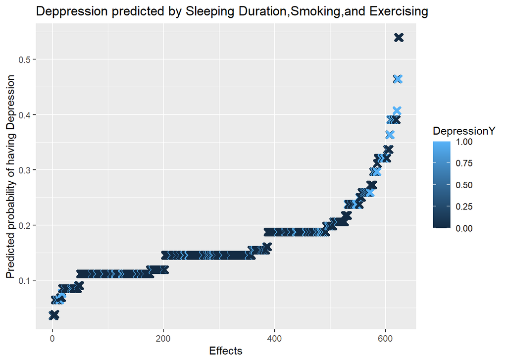

```r
predicted.dep <- data.frame(
  probability.of.DepressionY=log1$fitted.values,
  DepressionY=dep$DepressionY)

predicted.dep <- predicted.dep[
  order(predicted.dep$probability.of.DepressionY, decreasing=FALSE),]
predicted.dep$rank <- 1:nrow(predicted.dep)

## Lastly, we can plot the predicted probabilities for each sample having
## Depression and color by whether or not they actually had Depression
ggplot(data=predicted.dep, aes(x=rank, y=probability.of.DepressionY)) +
  geom_point(aes(color=DepressionY), alpha=1, shape=4, stroke=2) +
  xlab("Effects") +
  ylab("Predicted probability of having Depression")+ggtitle("Deppression predicted by Sleeping Duration,Smoking,and Exercising ")
```

#### Ordinary vs Logistic Regression

- The logistic regression was fitted with an ordinary linear regression, As shown in the model below, the probability to suffer from depression decreases as the sleep duration increases and exceeds the normal, recommended range of sleeping hours (7-9 hours a day).

```r
fit_glm = glm(DepressionY ~ Sleep_DurationX, data = dep, family = binomial)
fit_glm
```

```
##
## Call:  glm(formula = DepressionY ~ Sleep_DurationX, family = binomial,
##     data = dep)
##
## Coefficients:
##     (Intercept)  Sleep_DurationX
##          0.6619          -0.3285
##
## Degrees of Freedom: 623 Total (i.e. Null);  622 Residual
## Null Deviance:       562.3
## Residual Deviance: 548.2     AIC: 552.2
```

```r
fit_lm = lm(DepressionY ~ Sleep_DurationX, data = dep)
```

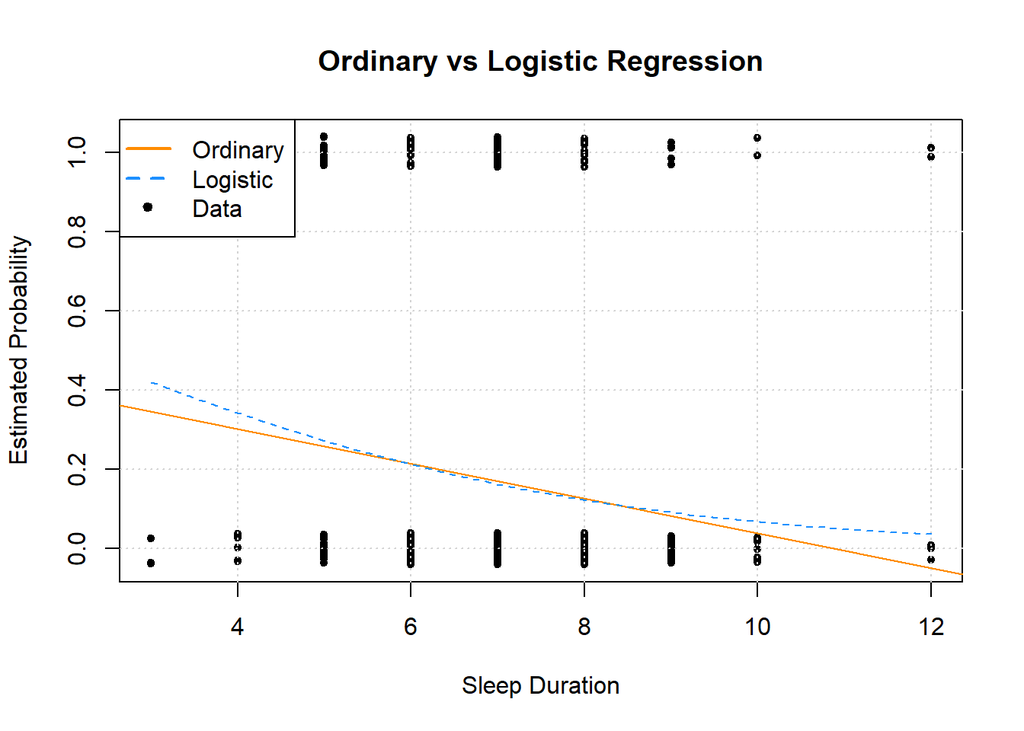

```r
plot(jitter(DepressionY,factor = 0.2) ~ Sleep_DurationX, data = dep,
  pch = 20, ylab = "Estimated Probability", xlab = "Sleep Duration",
  main = "Ordinary vs Logistic Regression")
grid()
abline(fit_lm, col = "darkorange")
curve(predict(fit_glm, data.frame(Sleep_DurationX = x), type = "response"),
  add = TRUE, col = "dodgerblue", lty = 2)
legend("topleft", c("Ordinary", "Logistic", "Data"), lty = c(1, 2, 0),
  pch = c(NA, NA, 20), lwd = 2, col = c("darkorange", "dodgerblue", "black"))
```

- Here is the estimated coefficients. (With rounding, for simplicity.)

```r
round(coef(fit_glm), 1)
```

```
##     (Intercept) Sleep_DurationX
##             0.7            -0.3
```

- The model below shows another model built predicting to show that smoking behaviors are positively correlated with depression diagnosis.

```r
fit_glm2 = glm(DepressionY ~ SmokingX, data = dep, family = binomial)
```

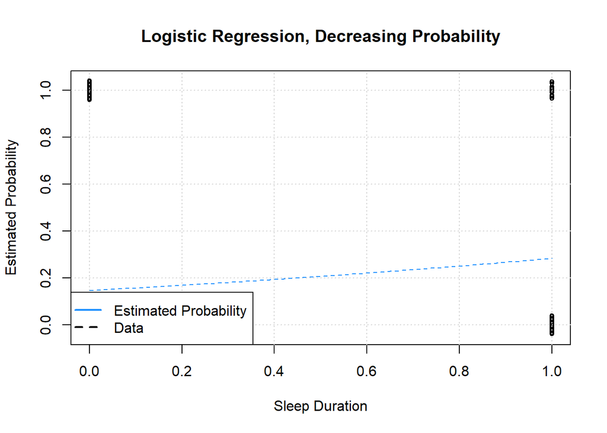

```r
plot(jitter(DepressionY,factor = 0.2) ~ SmokingX, data = dep,
  pch = 20, ylab = "Estimated Probability",xlab = "Sleep Duration",
  main = "Logistic Regression, Decreasing Probability")
grid()
curve(predict(fit_glm2, data.frame(SmokingX = x), type = "response"),
  add = TRUE, col = "dodgerblue", lty = 2)
legend("bottomleft", c( "Estimated Probability", "Data"), lty = c(1, 2, 0),
  pch = c(NA, NA, 20), lwd = 2, col = c( "dodgerblue", "black"))
```

#### Logistic Regression with Quadratic Relationship

```r
fit_glm3 = glm(DepressionY ~ Sleep_DurationX + I(Sleep_DurationX^2), data = dep, family = binomial)
```

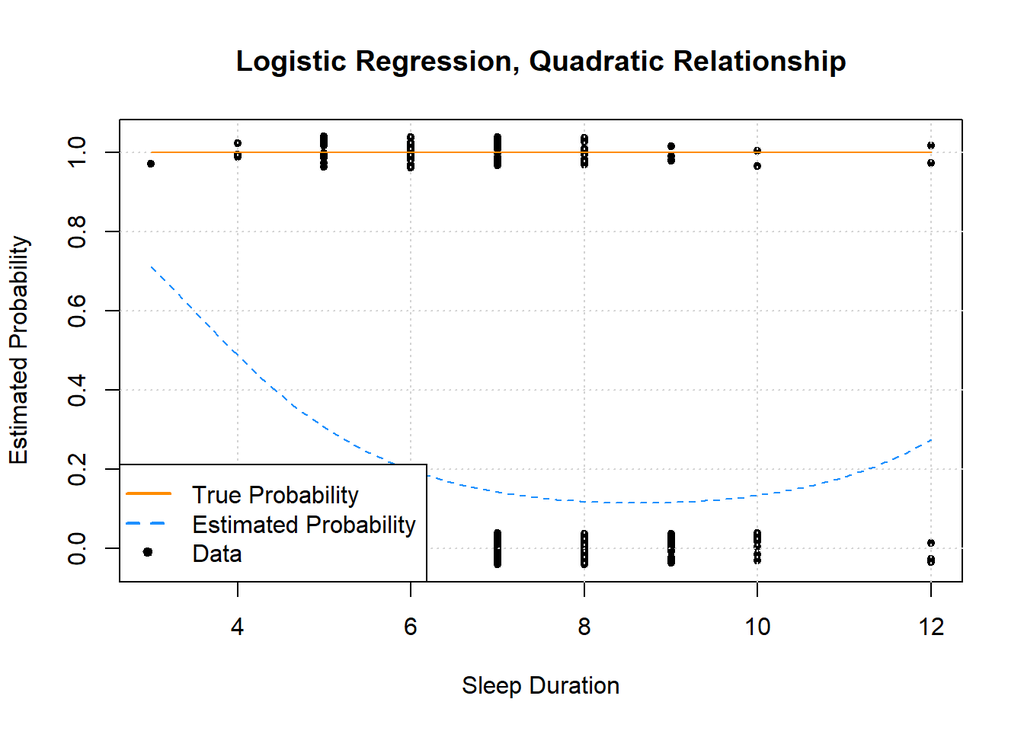

```r
plot(jitter(DepressionY,factor = 0.2)~ Sleep_DurationX, data = dep,
  pch = 20, ylab = "Estimated Probability",xlab = "Sleep Duration",
  main = "Logistic Regression, Quadratic Relationship")
grid()
curve(predict(fit_glm3, data.frame(Sleep_DurationX = x), type = "response"),
  add = TRUE, col = "dodgerblue", lty = 2)
curve(boot::inv.logit(-1.5 + 0.5 * x + x ^ 2),
  add = TRUE, col = "darkorange", lty = 1)
legend("bottomleft", c("True Probability", "Estimated Probability", "Data"), lty = c(1, 2, 0), pch = c(NA, NA, 20), lwd = 2, col = c("darkorange", "dodgerblue", "black"))
```

```r
coef(summary(log1))
```

```
##                    Estimate Std. Error    z value     Pr(>|z|)
## (Intercept)      0.41625163 0.69669945  0.5974623 0.5501987887
## Sleep_DurationX -0.30244425 0.08988055 -3.3649579 0.0007655535
## SmokingX         0.72126150 0.27190354  2.6526374 0.0079865615
## ExercisingX     -0.06994145 0.30431121 -0.2298353 0.8182197742
```

#### Heatmap

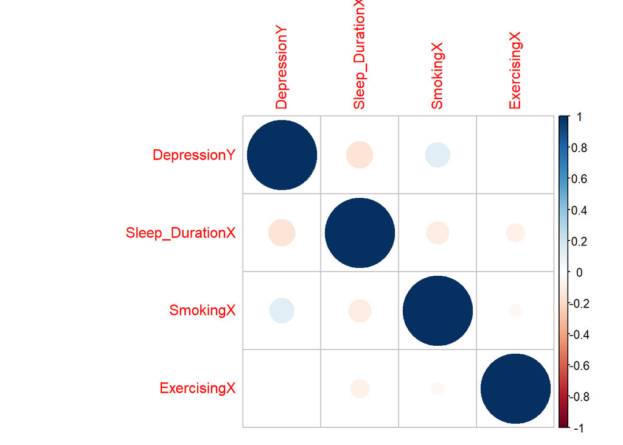

```r
correlations <- cor(dep[,2:5])
corrplot(correlations, method="circle")
```

### Counting how many depression we have across Southwest America

- People without depression are around 520, where depressed people are around 100.

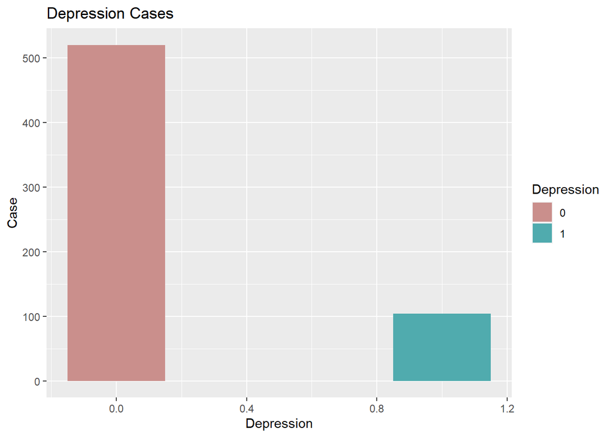

```r
# Bar-plot
ggplot(dep, aes( x=DepressionY, fill=as.factor(DepressionY))) +
  geom_bar(width=0.3)+ scale_fill_hue(c = 40)+ggtitle("Depression Cases")+labs(x ="Depression",y = "Case")+labs(fill = "Depression")
```

#### Sleep Duration across many States

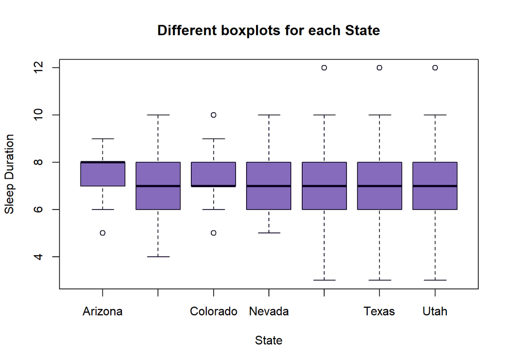

```r
boxplot(Sleep_DurationX~State,
data=dep,
main="Different boxplots for each State",
xlab="State",
ylab="Sleep Duration",
col="#866BBC",
border="#0B0120"
)
```